## Data Processing

The initial training data consisted of a tab separated file with two columns: the sender code (labeled 1-5) and the string of the email. With 1200 emails in the training set and another 105 as our test set, we proceeded to converting the emails into a frequency matrix.

After reading in the tsv, we converted the string to a character vector. We then wrote those vectors to a corpus so that we could use the R package `tm` to remove punctuation, numbers, and stop words; convert to lower case; and stem.

Next, we removed common words that were seen in every email, such as “subject”, and “US”, and words that were seen in 3 or fewer emails- this helps us eliminate the long tail of words that are used too infrequently to provide any sort of pattern.

We visualized some of the data to get a sense of its distribution and possibly pick out other useful characeristics. We first looked at the sender frequency.

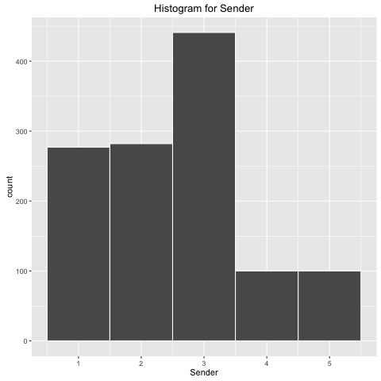

*Sender 3 has by far the most emails, while 4 and 5 both have about a third the amount of both 1 and 2*

We also did some wordclouds to visualize the differences in word frequecy.

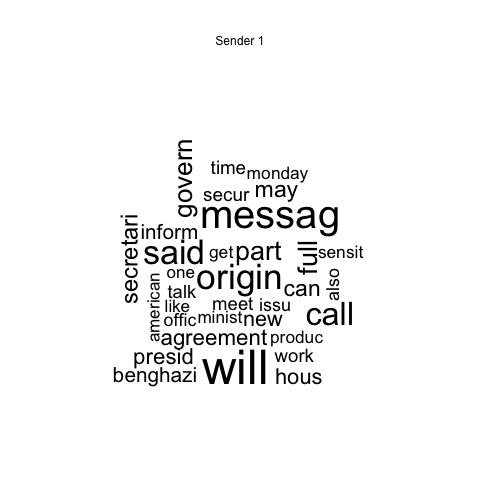

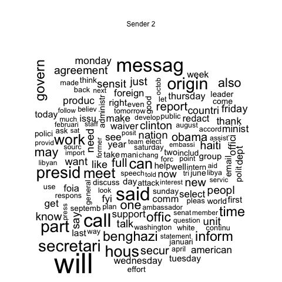

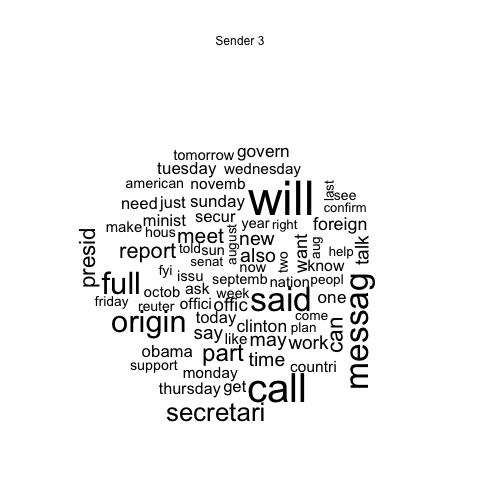

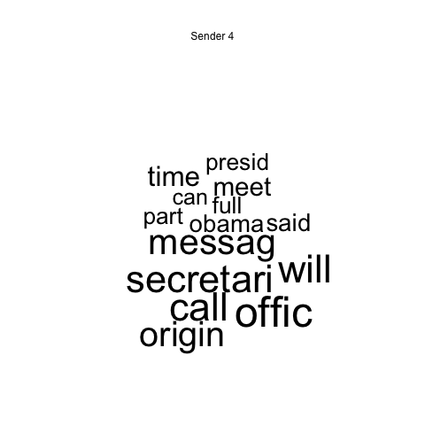

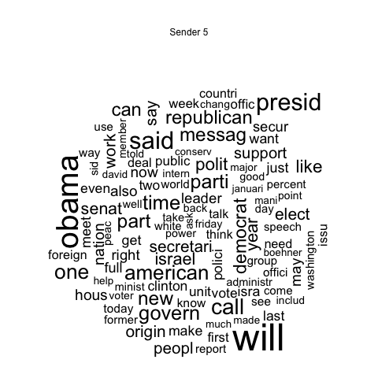

*Filtering the wordclouds so that only words appearning more than 200 time appeared yielded some interesting results*

We were curious about other qualities besides word frequency and took a quick look at the number of characters in each email.

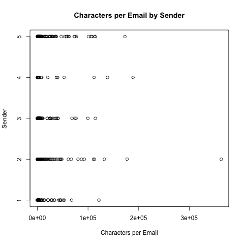

*The distributions definitely seem different enough that this could be a useful feature*

We also explored other possible features that could predict sender, including number of words, average word length, and rate of use for ampersands, semicolons, question marks, and upper case, numerals, and hyphens. We performed simple one-way ANOVA to determine whether or not to include the extra feature in our matrix.

We found that words per email, number of hyphens divided by number of words, and number of numerals divided by number of words all yielded small p-values. Ordinarilly we would be concerned with the significance issues that arise with multiple testing, but this was just a prelimary vetting. We added these three as features to our matrix. It is worth noting that this method is not ideal, as any significant higher-level interactions will be missed.

| Steps | Terms |
| --- | --- |
| Raw | 38066 |
| Stop Words | 37966 |
| Stemmed | 27504 |
| Frequency Selection | 9177 |
| Additional Features | 9180 |

Unfortunately, our reduced feature matrix was still extremely large, at 9180 columns.

### References

Tutorial for using tm https://eight2late.wordpress.com/2015/05/27/a-gentle-introduction-to-text-mining-using-r/